# FigureYa71ssGSEA_update

Rongfang Shen, Taojun Ye

2025-09-22

# Academic Citation

If you use this code in your work or research, we kindly request that you cite our publication:

Xiaofan Lu, et al. (2025). FigureYa: A Standardized Visualization Framework for Enhancing Biomedical Data Interpretation and Research Efficiency. iMetaMed. https://doi.org/10.1002/imm3.70005

## 需求描述

输入TCGA数据，用原文的方法计算，原图复现。

## Requirement Description

Input TCGA data and compute it using the method of the original text, reproduced in the original figure.

[figure not shown]

出自https://doi.org/10.3389/fimmu.2018.01578

fromhttps://doi.org/10.3389/fimmu.2018.01578

## 应用场景

关于量化浸润免疫细胞，2018年发表在Cancer Immunol Immunother中的一篇综述概况了目前所用的几种方法：[Quantifying tumor-infiltrating immune cells from transcriptomics data](https://link.springer.com/article/10.1007%2Fs00262-018-2150-z)。

ssGSEA量化免疫细胞浸润最大的一个优点就是自己可以定制量化免疫浸润细胞种类。像MCPcounter只能量化10种免疫细胞，cibersort量化22种细胞，但是目前平台只限于用在芯片数据，虽然很多RNA-seq数据也直接用了。

ssGSEA只要你有marker genes就可以量化。**注意：**量化出来的结果是不可以跨数据比较的，就跟转录组的批次效应一样。

目前公认并且用的最多的免疫细胞marker就是2013年发表在Immunity上的SpatiotemporalDynamicsof IntratumoralImmuneCells Reveal the Immune Landscape in Human Cancer 所提供的免疫细胞marker genes（Table S1），能提取到24种免疫细胞信息。下文用的是这24种免疫细胞。

例文提取了27种免疫细胞，联系原作者能获得27种免疫细胞表面marker genes。输入原作者提供的这些marker genes来跑这套代码，结果基本同原文一致，可以很好的分为3类。

## Application Scenarios

With regard to quantifying infiltrating immune cells, a 2018 review published in Cancer Immunol Immunother provides an overview of several methods currently used:[Quantifying tumor-infiltrating immune cells from transcriptomics data](https://link.springer.com/article/10.1007%2Fs00262-018-2150-z).

One of the biggest advantages of ssGSEA for quantifying immune cell infiltration is that one can customize the quantification of immune infiltrating cell types. Like MCPcounter can only quantify 10 types of immune cells, cibersort quantifies 22 types of cells, but currently the platform is limited to microarray data, although many RNA-seq data are also used directly.

ssGSEA can quantify as long as you have marker genes. **Note:** The results from quantification are not comparable across data, just like the batch effect on the transcriptome.

The currently recognized and most used immune cell marker is [SpatiotemporalDynamicsof IntratumoralImmuneCells Reveal the Immune Landscape in Human Cancer] published in Immunity in 2013 ( https://linkinghub.elsevier.com/retrieve/pii/S1074-7613(13)00437-8) The immune cell marker genes (Table S1) provided by https://linkinghub.elsevier.com/retrieve/pii/S1074-7613(13)00437-8) were able to extract information on 24 immune cells. These 24 immune cells are used in the following text.

The example paper extracted 27 kinds of immune cells, contacting the original author can get 27 kinds of immune cell surface marker genes. input these marker genes provided by the original author to run this set of code, the result is basically the same as the original article, and it can be well categorized into 3 classes.

[figure not shown]

## Environment settings

```r
source("install_dependencies.R")
```

[output not shown]

```r
# 加载生物信息学分析所需的R包 / Load R packages for bioinformatics analysis
library(GSVA)          # 基因集变异分析 / Gene Set Variation Analysis
library(org.Hs.eg.db)
```

```r
library(TCGAbiolinks)   # TCGA数据下载与处理 / TCGA data download and processing
library(ComplexHeatmap) # 复杂热图绘制 / Complex heatmap visualization
library(dplyr)         # 数据操作与转换 / Data manipulation and transformation
library(stringr)       # 字符串处理 / String manipulation
library(rtracklayer)   # 基因组数据交互 / Genomic data interoperability
library(SummarizedExperiment) # 基因组数据容器 / Genomic data container
library(clusterProfiler) # 聚类分析与可视化 / Cluster profiling and visualization
library(RColorBrewer)  # 颜色调色板 / Color palettes
library(maftools)      # MAF文件分析与可视化 / MAF file analysis and visualization
library(circlize)      # 环形可视化 / Circular visualization
library(matrixStats)   # 矩阵统计运算 / Matrix statistical operations
library(GetoptLong)    # 字符串插值 / String interpolation
library(GenomicRanges) # 基因组范围操作 / Genomic ranges manipulation

# 设置系统环境参数 / Set system environment parameters
Sys.setenv(LANGUAGE = "en")  # 强制显示英文报错信息 / Force English error messages
options(stringsAsFactors = FALSE)  # 防止字符自动转为因子 / Prevent automatic conversion of strings to factors
```

## 输入数据预处理

用ssGSEA量化免疫浸润，需要两个输入数据：

- easy_input_immunity.rdata，24种免疫细胞marker genes的ENTREZ ID，保存为list。来源：[2013 Immunity那篇文章的Table S1](https://www.cell.com/cms/10.1016/j.immuni.2013.10.003/attachment/8dc04d32-6aff-4eda-99f5-6401bcae9751/mmc1.pdf)，手动整理成csv格式，并用GPL96（HG-U133A Affymetrix platform）按照探针得到gene symbol，文章有提到这批数据是从这个芯片平台得到的。
- easy_input_expr.csv，基因表达矩阵，每行一个基因，每列一个sample。第一列基因ID跟easy_input_immunity.rdata里的基因ID一致，此处都用ENTREZ ID。

**如果你已经准备好了这两个文件，就可以直接进入“用ssGSEA来量化浸润水平”。**

下面带你获得这两个输入文件：

## Input data preprocessing

Quantifying immune infiltration with ssGSEA requires two input data:

- easy_input_immunity.rdata, ENTREZ IDs of 24 immune cell marker genes, saved as a list. source:[Table S1 of the 2013 Immunity article](https://www.cell.com/cms/10.1016/j.%20immuni.2013.10.003/attachment/8dc04d32-6aff-4eda-99f5-6401bcae9751/mmc1.pdf), manually organized into csv format, and used GPL96 (HG-U133A Affymetrix platform) to get the gene symbol, the article has mentioned that this batch of data was obtained from this chip platform.
- easy_input_expr.csv, gene expression matrix, one gene per row, one sample per column, the first column gene ID is the same as the gene ID in easy_input_immunity.rdata, and ENTREZ ID is used here.

**If you have these two files ready, you can go directly to “Quantifying infiltration levels with ssGSEA”.**

The following takes you to the two input files:

### 免疫细胞marker genes

这步获得的easy_input_immunity.rdata里面是各种免疫细胞marker genes list，可重复使用。

### Immune cell marker genes

The easy_input_immunity.rdata obtained in this step contains a list of various immune cell marker genes that can be reused.

```r
# 读取免疫细胞标记基因文件 / Read immune cell marker gene file
# 输入：包含CellType和ENTREZ_GENE_ID列的CSV文件 / Input: CSV file with CellType and ENTREZ_GENE_ID columns
immunity <- read.csv("immunitygene.csv", header = TRUE)  # header=T表示第一行是列名 / header=T means first row contains column names

# 数据清洗 - 移除非免疫细胞类型 / Data cleaning - Remove non-immune cell types
# 排除血管、正常黏膜等非目标细胞类型 / Exclude non-target cell types like blood vessels, normal mucosa etc.
immunity <- immunity[!immunity$CellType %in%
                     c("Blood vessels", "Normal mucosa",
                       "SW480 cancer cells", "Lymph vessels"), ]

# 数据转换 - 转为细胞类型分组的基因列表 / Data transformation - Convert to cell-type grouped gene list
# 步骤1：按CellType拆分数据框 / Step 1: Split dataframe by CellType
# 步骤2：提取每个细胞类型的Entrez基因ID / Step 2: Extract Entrez gene IDs for each cell type
# 注意：原始数据来自Affymetrix芯片平台，此处选用Entrez_ID保持一致性 / Note: Original data from Affymetrix platform, using Entrez_ID for consistency
immunity <- immunity %>%
  split(., .$CellType) %>%  # 按CellType分组 / Group by CellType
  lapply(., function(x)(x$ENTREZ_GENE_ID))  # 提取每组的基因ID / Extract gene IDs per group

# 去除重复基因 / Remove duplicate genes
immunity <- lapply(immunity, unique)  # 对每个细胞类型的基因列表去重 / Deduplicate gene lists per cell type

# 保存处理后的数据 / Save processed data
# 保存为R原生格式便于快速重加载 / Save as R native format for fast reloading
save(immunity, file = "easy_input_immunity.rdata")  # 输出文件名包含"easy_input"提示简化后的数据 / Output filename contains "easy_input" indicating simplified data
```

### 表达矩阵

TCGA表达数据的获取方式：

- 用TGCAbiolinks下载表达数据read count，然后转成TPM，数据下载和转换的方法可参考FigureYa23count2TPM；第一列是ENTREZ ID，其后每列一个sample。需要把gene_id换成gene symbol或ENTREZ ID。GDC来源的TCGA数据用的是v22版本，从GENCODEhttps://www.gencodegenes.org/进去，点击下载v22版本gtf文件：ftp://ftp.ebi.ac.uk/pub/databases/gencode/Gencode_human/release_22/gencode.v22.annotation.gtf.gz
- 或者下载所有癌症的TPM，提取感兴趣癌症的TPM，可参考FigureYa56immune_inflitrationV2。

如果你已经生成过gtf_v22.csv文件，就可以跳过下面这段。

### Expression matrix

TCGA expression data acquisition method:

- Use TGCAbiolinks to download the expression data read count, and then converted to TPM, the method of data download and conversion can be found in FigureYa23count2TPM; the first column is ENTREZ ID, and each subsequent column is one sample. need to replace gene_id with gene symbol or ENTREZ ID. The TCGA data from the GDC source used version v22, go in from GENCODE https://www.gencodegenes.org/ and click to download the v22 gtf file: <ftp://ftp.ebi.ac.uk/pub/databases/gencode/Gencode_ human/release_22/gencode.v22.annotation.gtf.gz>
- Or download the TPMs for all cancers and extract the TPMs for the cancer of interest, see FigureYa56immune_inflitrationV2.

If you have already generated the gtf_v22.csv file, you can skip the following paragraph.

```r
# 先获得protein_coding gene的gene_id跟gene symbol的对应关系
gtf_v22 <- rtracklayer::import("gencode.v22.annotation.gtf")
gtf_v22 <- as.data.frame(gtf_v22)
gtf_v22 <- dplyr::select(gtf_v22, c("gene_id", "gene_type", "gene_name")) %>%
  filter(., gene_type ==  "protein_coding") %>%
  unique()
gtf_v22 <- gtf_v22[!duplicated(gtf_v22), ]

# 再加入ENTREZ ID，如果immunity.rdata里用的是gene symbol，就不需要运行下面这行
gtf_v22 <- bitr(gtf_v22$gene_name, fromType = "SYMBOL", toType = "ENTREZID", OrgDb = "org.Hs.eg.db") %>%
  merge(., gtf_v22, by.x = "SYMBOL", by.y = "gene_name") %>%
  mutate(., gene_id = str_sub(gene_id, 1, 15))

# 这步获得gtf_v22.csv文件，包含v22版本protein_coding gene的gene_id、gene symbol和ENTREZ ID的对应关系，可重复使用。
write.csv(gtf_v22, "gtf_v22.csv", quote = F, row.names = F)
```

```r
# 读取基因表达数据矩阵，行名为基因ID，列名为样本ID
# 参数说明:
# "not_easy_input_expr.csv" - 原始表达矩阵文件，需包含基因ID作为行名
# Read gene expression data matrix with gene IDs as row names
# Parameter description:
# "not_easy_input_expr.csv" - Original expression matrix file with gene IDs as row names
tcga_expr <- read.csv("not_easy_input_expr.csv", header = T, stringsAsFactors = F, row.names = 1)
tcga_expr[1:3,1:3]
```

```
##                 TCGA.AZ.4315.01A.01R.1410.07 TCGA.AA.3667.01A.01R.0905.07
## ENSG00000000003                        119.8                         69.0
## ENSG00000000005                          1.0                          2.2
## ENSG00000000419                        136.5                        114.6
##                 TCGA.F4.6854.01A.11R.1928.07
## ENSG00000000003                        172.8
## ENSG00000000005                          1.3
## ENSG00000000419                        273.7
```

```r
# 读取之前生成的基因ID映射表(含ENTREZID和gene_id)
# Load pre-generated gene ID mapping table (contains ENTREZID and gene_id)
gtf_v22 <- read.csv("gtf_v22.csv")

# 加载data.table包用于高效数据处理
# Load data.table package for efficient data processing
library(data.table)
# 将原始基因ID转换为ENTREZ ID并按ENTREZ ID合并重复基因(取中位数)
# 注意：此步骤处理时间较长，建议在高性能环境运行
# 参数说明:
# by.x = 2 - 使用gtf_v22的第2列(gene_id)作为连接键
# by.y = 0 - 使用tcga_expr的行名(基因ID)作为连接键
# aggregate(.~ENTREZID, ., median) - 按ENTREZ ID分组并计算表达值中位数
# Convert gene IDs to ENTREZ IDs and aggregate duplicate genes by median expression
# Note: This step is time-consuming, recommend running on high-performance environment
# Parameter description:
# by.x = 2 - Use 2nd column (gene_id) of gtf_v22 as join key
# by.y = 0 - Use row names (gene IDs) of tcga_expr as join key
# aggregate(.~ENTREZID, ., median) - Group by ENTREZ ID and compute median expression
tcga_expr <- merge(gtf_v22[, c("ENTREZID", "gene_id")], tcga_expr, by.x = 2, by.y = 0) %>% .[, -1] %>%
    aggregate(.~ENTREZID, ., median)  # This step may take a while

# 设置ENTREZ ID为行名并移除冗余列
# Set ENTREZ ID as row names and remove redundant columns
rownames(tcga_expr) <- tcga_expr$ENTREZID
tcga_expr <- tcga_expr[, -1]
head(tcga_expr)
```

```
##    TCGA.AZ.4315.01A.01R.1410.07 TCGA.AA.3667.01A.01R.0905.07
## 1                          0.00                          0.1
## 2                         73.80                         57.7
## 9                         23.90                          3.6
## 10                         6.20                          2.4
## 12                         0.05                          0.0
## 13                         0.10                          0.4
##    TCGA.F4.6854.01A.11R.1928.07 TCGA.AA.3815.01A.01R.1022.07
## 1                          0.10                          0.0
## 2                        246.90                         95.3
## 9                          6.00                         18.5
## 10                         2.10                         14.1
## 12                         0.05                          0.0
## 13                         0.60                          8.6
##    TCGA.AA.3509.01A.01R.1410.07 TCGA.DM.A0XF.01A.11R.A155.07
```

[output cut: 2239 more lines]

```r
# 保存处理后的表达矩阵到文件，保留1位小数以减小文件大小
# Save processed expression matrix to file with 1 decimal place to reduce file size
write.csv(round(tcga_expr,1), "easy_input_expr.csv", quote = F)
```

## 用ssGSEA来量化浸润水平

## Quantifying infiltration levels with ssGSEA

```r
# 读取TCGA基因表达矩阵 / Load TCGA gene expression matrix
# 注意：第一列作为行名（基因名） / Note: First column as row names (gene names)
tcga_expr <- read.csv("easy_input_expr.csv", row.names = 1)

# 检查数据前3行前2列 / Check first 3 rows and 2 columns
tcga_expr[1:3, 1:2]  # 验证数据读取是否正确 / Verify data loading
```

```
##   TCGA.AZ.4315.01A.01R.1410.07 TCGA.AA.3667.01A.01R.0905.07
## 1                          0.0                          0.1
## 2                         73.8                         57.7
## 9                         23.9                          3.6
```

```r
# 加载预处理的免疫基因集 / Load pre-processed immune gene sets
(load("easy_input_immunity.rdata"))  # 括号使加载结果自动打印 / Parentheses auto-print loaded objects
```

```
## [1] "immunity"
```

```r
immunity[1]  # 查看第一个免疫细胞类型的基因 / View genes of first immune cell type
```

```
## $aDC
## [1] 27074  6346  3620  4940 10148
```

```r
# 执行ssGSEA分析 / Perform ssGSEA analysis
# 步骤：1.转置矩阵 2.转换为矩阵格式 3.使用ssGSEA方法计算富集分数
# Steps: 1.Transpose matrix 2.Convert to matrix 3.Calculate enrichment scores with ssGSEA
# 将所有基因 ID 转为字符型
immunity <- lapply(immunity, as.character)

params <- ssgseaParam(exprData = as.matrix(tcga_expr), geneSets = immunity)
tcga_gsva <- as.data.frame(t(gsva(params)))
```

```
## ℹ GSVA version 2.0.7
```

```
## ! 118 genes with constant values throughout the samples
```

```
## ! Some gene sets have size one. Consider setting minSize > 1
```

```
## ℹ Calculating  ssGSEA scores for 24 gene sets
```

```
## ℹ Calculating ranks
```

```
## ℹ Calculating rank weights
```

```
## Calculating ssGSEA scores ■■■■■■■■■■■■■■■■■■■■■■■■■■■■■■■   99% | ETA:  0s                                                                           ℹ Normalizing ssGSEA scores
## ✔ Calculations finished
```

```r
# 检查结果数据结构 / Check result structure
str(tcga_gsva)  # 显示数据维度及前几行 / Show dimensions and first rows
```

```
## 'data.frame':    644 obs. of  24 variables:
##  $ aDC                : num  0.0831 0.00772 0.09695 0.25454 0.05332 ...
##  $ B cells            : num  -0.184 -0.206 -0.203 -0.147 -0.198 ...
##  $ CD8 T cells        : num  0.294 0.257 0.262 0.33 0.269 ...
##  $ Cytotoxic cells    : num  0.0543 0.0146 -0.0169 0.2026 -0.097 ...
##  $ DC                 : num  -0.0817 -0.0182 -0.1056 0.0335 -0.0903 ...
##  $ Eosinophils        : num  0.0576 0.113 0.0665 0.0908 0.0895 ...
##  $ iDC                : num  0.1329 0.1241 0.0854 0.1243 0.0819 ...
##  $ Macrophages        : num  0.1546 0.0924 0.1266 0.2032 0.1233 ...
##  $ Mast cells         : num  -0.133 -0.144 -0.16 -0.114 -0.115 ...
##  $ Neutrophils        : num  -0.1278 0.0227 -0.1012 -0.0417 -0.0773 ...
##  $ NK CD56bright cells: num  -0.02717 0.19875 0.00336 0.04345 -0.02076 ...
##  $ NK CD56dim cells   : num  0.0558 0.1467 0.1377 0.0715 0.0778 ...
##  $ NK cells           : num  0.133 0.188 0.153 0.148 0.118 ...
##  $ pDC                : num  0.0808 0.1537 0.3144 0.1053 0.1795 ...
##  $ T cells            : num  -0.02109 -0.01967 0.00265 0.18272 0.00268 ...
##  $ T helper cells     : num  0.295 0.193 0.281 0.309 0.315 ...
##  $ Tcm                : num  0.00343 0.02333 0.06001 0.03764 0.05984 ...
##  $ Tem                : num  0.111 0.184 0.182 0.136 0.154 ...
##  $ TFH                : num  -0.05815 0.00412 -0.03212 0.0198 -0.04805 ...
##  $ Tgd                : num  -0.0524 -0.1537 -0.0349 -0.051 -0.0603 ...
##  $ Th1 cells          : num  0.00458 0.02521 0.01387 0.0526 0.00225 ...
##  $ Th17 cells         : num  -0.0432 0.1729 -0.0493 0.0508 -0.0535 ...
##  $ Th2 cells          : num  0.0926 -0.0302 0.0393 0.0639 0.057 ...
##  $ TReg               : num  -0.10151 -0.00881 -0.08297 0.02634 -0.16694 ...
```

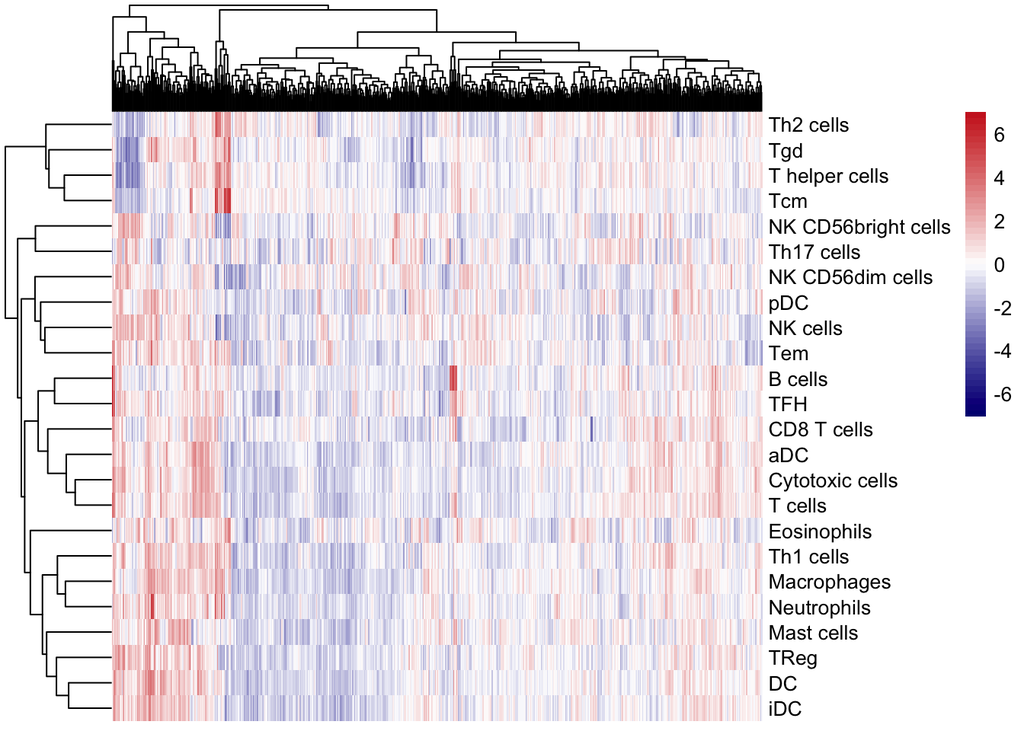

```r
# 保存ssGSEA结果 / Save ssGSEA results
write.csv(
  tcga_gsva,
  "ssGSEA_output.csv",
  quote = FALSE,  # 不添加引号 / No quotes around values
  row.names = TRUE  # 保留行名（样本ID） / Keep row names (sample IDs)
)

# 可视化结果 / Visualize results
library(pheatmap)  # 加载热图绘制包 / Load heatmap package
# 绘制标准化热图 / Draw standardized heatmap
pheatmap(
  t(tcga_gsva),  # 需要转置使样本为列 / Transpose to show samples as columns
  scale = "row",  # 行标准化（Z-score） / Row standardization (Z-score)
  show_colnames = FALSE,  # 隐藏样本名 / Hide sample names
  color = colorRampPalette(
    c("navy", "white", "firebrick3")  # 蓝-白-红渐变色 / Blue-white-red gradient
  )(50))  # 生成50个颜色梯度 / Generate 50 color gradients
```

如果你只想计算免疫浸润，那么到这里就结束了。

如果你想把免疫浸润跟突变、临床信息结合起来看，复现例文的原图，就需要运行下面这部分：

If you just want to calculate the immune infiltration, then that’s the end of it here.

If you want to look at the immune infiltration in conjunction with the mutation and clinical information and reproduce the original graph of the example text, you need to run the following section:

## 原图复现

下面用TCGAbiolink从GDC下载数据，需要找个网络好点的地方。

## Original image reproduction

Here’s how to download the data from GDC using TCGAbiolink, you need to find a place with a good network.

### Download mutation information

[figure not shown]

```r
# 定义目标基因和突变类型 / Define target genes and mutation types
targetMut <- c("TP53", "KRAS", "BRAF", "EGFR")  # 需要提取的癌基因 / Oncogenes to extract
nonsilentmutation <- c("Frame_Shift_Del", "Frame_Shift_Ins", "Missense_Mutation",
                      "Nonsense_Mutation", "Splice_Site", "In_Frame_Del",
                      "In_Frame_Ins", "Translation_Start_Site", "Nonstop_Mutation")
# 注：Splice_Region突变通常影响非编码RNA / Note: Splice_Region affects ncRNA splicing

# 获取TCGA突变数据 / Retrieve TCGA mutation data
# 方法：使用varscan2流程获取COAD和READ数据 / Method: Using varscan2 pipeline for COAD and READ
# 下载 MAF 文件（已整合多个 caller，如 varscan2、mutect2 等）
# query <- GDCquery(
#   project = "TCGA-COAD",
#   data.category = "Simple Nucleotide Variation",
#   data.type = "Masked Somatic Mutation",
#   workflow.type = "Aliquot Ensemble Somatic Variant Merging and Masking"
# )
# # 下载数据
# GDCdownload(query)
# # 准备数据
# coadmut <- GDCprepare(query)
#
# query <- GDCquery(
#   project = "TCGA-READ",
#   data.category = "Simple Nucleotide Variation",
#   data.type = "Masked Somatic Mutation",
#   workflow.type = "Aliquot Ensemble Somatic Variant Merging and Masking"
# )
# # 下载数据
# GDCdownload(query)
# # 准备数据
# readmut <- GDCprepare(query)

# coadmut <- GDCquery_Maf(tumor = "COAD", pipelines = "varscan2")  # 结肠腺癌 / Colon adenocarcinoma
# readmut <- GDCquery_Maf(tumor = "READ", pipelines = "varscan2")  # 直肠腺癌 / Rectal adenocarcinoma
library(readr)
coadmut <- read_tsv("TCGA-COAD.somaticmutation_wxs.tsv.gz")
readmut <- read_tsv("TCGA-READ.somaticmutation_wxs.tsv.gz")
# 验证并合并数据 / Validate and merge data
all(colnames(coadmut) == colnames(readmut))  # 确认列名一致 / Confirm identical column names
```

```
## [1] TRUE
```

```r
crcmut <- rbind(coadmut, readmut)  # 合并结直肠癌数据 / Merge colorectal cancer data

# 处理样本ID / Process sample IDs
# 提取前12位作为样本ID（TCGA标准） / Extract first 12 chars as TCGA sample ID
crcmut <- data.frame(sample = str_sub(crcmut$Tumor_Sample_Barcode, 1, 12), crcmut)
all_mutSample <- unique(crcmut$sample)  # 获取所有突变样本 / Get all mutated samples

# 数据过滤 - 保留非同义突变 / Data filtering - Keep nonsilent mutations
table(crcmut$Variant_Classification)  # 查看突变类型分布 / View mutation type distribution
```

```
## < table of extent 0 >
```

```r
crcmut <- crcmut[crcmut$Variant_Classification %in% nonsilentmutation, ]  # 过滤沉默突变 / Filter silent mutations

# 提取目标基因突变 / Extract target gene mutations
crc_mut_gene <- crcmut[crcmut$Hugo_Symbol %in% targetMut, ]  # 筛选目标基因 / Filter target genes

# 定义突变组和野生型组 / Define mutant and wild-type groups
# TP53突变分析 / TP53 mutation analysis
TP53mutSample <- unique(crc_mut_gene[crc_mut_gene$Hugo_Symbol == "TP53", "sample"])
TP53wildSample <- setdiff(all_mutSample, TP53mutSample)
# 逻辑：存在于数据但无突变的样本为野生型 / Logic: Samples in data without mutation are wild-type
# 注：不在数据中的样本视为NA（未检测） / Note: Samples not in data are considered NA (not tested)

# 其他基因相同处理 / Same processing for other genes
KRASmutSample <- unique(crc_mut_gene[crc_mut_gene$Hugo_Symbol == "KRAS", "sample"])
KRASwildSample <- setdiff(all_mutSample, KRASmutSample)

BRAFmutSample <- unique(crc_mut_gene[crc_mut_gene$Hugo_Symbol == "BRAF", "sample"])
BRAFwildSample <- setdiff(all_mutSample, BRAFmutSample)

EGFRmutSample <- unique(crc_mut_gene[crc_mut_gene$Hugo_Symbol == "EGFR", "sample"])
EGFRwildSample <- setdiff(all_mutSample, EGFRmutSample)
```

### Download msi clinical information

```r
# # 获取TCGA-COAD项目的MSI数据 / Retrieve MSI data for TCGA-COAD project
# msiquery1 <- GDCquery(
#   project = "TCGA-COAD",       # 结肠腺癌项目 / Colon adenocarcinoma project
#   data.category = "Other",     # 其他数据类型 / Other data category
#   legacy = TRUE,               # 使用旧版数据 / Use legacy data
#   access = "open",             # 公开访问数据 / Open access data
#   data.type = "Auxiliary test" # 辅助测试数据类型 / Auxiliary test data type
# )
#
# # 下载查询到的数据 / Download the queried data
# GDCdownload(msiquery1)
#
# # 提取并整理MSI结果 / Extract and organize MSI results
# coad_msi_results <- GDCprepare_clinic(
#   query = msiquery1,           # 查询对象 / Query object
#   clinical.info = "msi"        # 提取MSI信息 / Extract MSI information
# )
#
# # 获取TCGA-READ项目的MSI数据 / Retrieve MSI data for TCGA-READ project
# msiquery2 <- GDCquery(
#   project = "TCGA-READ",       # 直肠腺癌项目 / Rectal adenocarcinoma project
#   data.category = "Other",
#   legacy = TRUE,
#   access = "open",
#   data.type = "Auxiliary test"
# )
#
# # 下载查询到的数据 / Download the queried data
# GDCdownload(msiquery2)
#
# # 提取并整理MSI结果 / Extract and organize MSI results
# read_msi_results <- GDCprepare_clinic(
#   query = msiquery2,
#   clinical.info = "msi"
# )

clinical_data <- read.delim("TCGA.COADREAD.sampleMap_COADREAD_clinicalMatrix",
                            stringsAsFactors = FALSE, check.names = FALSE)
msi_results <- data.frame(
  sample = clinical_data[,1],
  MSI = clinical_data$MSI_updated_Oct62011
)
# # 合并两个癌症类型的数据 / Merge data from both cancer types
# msi_results <- rbind(read_msi_results, coad_msi_results) %>%  # 行合并 / Row binding
#   .[, c(1, 3)] %>%              # 选择第1列(样本ID)和第3列(MSI状态) / Select columns 1(sample ID) and 3(MSI status)
#   setNames(c("sample", "MSI"))  # 重命名列 / Rename columns
```

### Download additional clinical information

```r
# # 获取TCGA-COAD临床数据 / Retrieve TCGA-COAD clinical data
# coadclinical <- GDCquery(
#   project = "TCGA-COAD",        # 结肠腺癌项目 / Colon adenocarcinoma project
#   data.category = "Clinical",   # 临床数据类型 / Clinical data category
#   file.type = "xml"             # 文件格式为XML / XML file format
# )
#
# # 下载临床数据 / Download clinical data
# GDCdownload(coadclinical)
#
# # 提取并整理患者临床信息 / Extract and organize patient clinical info
# coadclinical <- GDCprepare_clinic(
#   query = coadclinical,         # 查询对象 / Query object
#   clinical.info = "patient"     # 患者级别临床信息 / Patient-level clinical data
# )
#
# # 获取TCGA-READ临床数据 / Retrieve TCGA-READ clinical data
# readclinical <- GDCquery(
#   project = "TCGA-READ",        # 直肠腺癌项目 / Rectal adenocarcinoma project
#   data.category = "Clinical",
#   file.type = "xml"
# )
#
# # 下载临床数据 / Download clinical data
# GDCdownload(readclinical)
#
# # 提取并整理患者临床信息 / Extract and organize patient clinical info
# readclinical <- GDCprepare_clinic(
#   query = readclinical,
#   clinical.info = "patient"
# )
#
# # 验证列名一致性 / Verify column name consistency
# # 确保两个数据框结构相同 / Ensure identical dataframe structures
# all(colnames(readclinical) == colnames(coadclinical))
#
# # 合并临床数据 / Merge clinical data
# clinical <- rbind(coadclinical, readclinical)  # 行合并 / Row binding
```

### 组合所需要的临床信息

### Clinical information required for the portfolio

```r
# 选择关键临床变量 / Select key clinical variables
targetAnno <- clinical_data[, c(
  "sampleID",            # 患者ID / Patient ID
  "pathologic_stage",   # 病理分期 / Pathologic stage
  "gender",                        # 性别 / Gender
  "vital_status",                   # 生存状态 / Vital status
  "anatomic_neoplasm_subdivision",  # 肿瘤解剖位置 / Tumor anatomic location
  "colon_polyps_present"           # 是否存在结肠息肉 / Presence of colon polyps
)]

# 查看肿瘤位置分布 / Check tumor location distribution
table(targetAnno$anatomic_neoplasm_subdivision)
```

```
##
##                               [Discrepancy]       Ascending Colon
##                    14                    14                   104
##                 Cecum      Descending Colon       Hepatic Flexure
##                   127                    22                    33
## Rectosigmoid Junction                Rectum         Sigmoid Colon
##                    57                   121                   190
##       Splenic Flexure      Transverse Colon
##                     9                    45
```

```r
# 划分左右半结肠 / Classify left/right colon cancer
# 右侧：盲肠至横结肠 / Right: Cecum to Transverse Colon
# 左侧：脾曲至直肠 / Left: Splenic Flexure to Rectum
targetAnno$tumor_site <- targetAnno$anatomic_neoplasm_subdivision %>%
  str_replace(., "(Cecum|Ascending Colon|Hepatic Flexure|Transverse Colon)", "right") %>%
  str_replace(., "(Splenic Flexure|Descending Colon|Sigmoid Colon|Rectosigmoid Junction|Rectum)", "left")

# 合并MSI数据 / Merge MSI data
targetAnno <- merge(
  targetAnno,
  msi_results,
  by.x = "sampleID",  # 临床数据中的患者ID / Patient ID in clinical data
  by.y = "sample",               # MSI数据中的样本ID / Sample ID in MSI data
  all.x = TRUE                   # 保留所有临床样本（左连接） / Keep all clinical samples (left join)
)

# 初始化突变状态列 / Initialize mutation status columns
targetAnno$TP53mut <- NA  # TP53突变状态 / TP53 mutation status
targetAnno$KRASmut <- NA  # KRAS突变状态 / KRAS mutation status
targetAnno$BRAFmut <- NA  # BRAF突变状态 / BRAF mutation status
targetAnno$EGFRmut <- NA  # EGFR突变状态 / EGFR mutation status

# 标记TP53突变状态 / Annotate TP53 mutation status
targetAnno[targetAnno$bcr_patient_barcode %in% TP53mutSample, "TP53mut"] <- "mutant"     # 突变型 / Mutant
targetAnno[targetAnno$bcr_patient_barcode %in% TP53wildSample, "TP53mut"] <- "wildtype"  # 野生型 / Wild-type

# 标记KRAS突变状态 / Annotate KRAS mutation status
targetAnno[targetAnno$bcr_patient_barcode %in% KRASmutSample, "KRASmut"] <- "mutant"
targetAnno[targetAnno$bcr_patient_barcode %in% KRASwildSample, "KRASmut"] <- "wildtype"

# 标记BRAF突变状态 / Annotate BRAF mutation status
targetAnno[targetAnno$bcr_patient_barcode %in% BRAFmutSample, "BRAFmut"] <- "mutant"
targetAnno[targetAnno$bcr_patient_barcode %in% BRAFwildSample, "BRAFmut"] <- "wildtype"

# 标记EGFR突变状态 / Annotate EGFR mutation status
targetAnno[targetAnno$bcr_patient_barcode %in% EGFRmutSample, "EGFRmut"] <- "mutant"
targetAnno[targetAnno$bcr_patient_barcode %in% EGFRwildSample, "EGFRmut"] <- "wildtype"

# 查看数据摘要 / View data summary
summary(targetAnno)
```

```
##    sampleID         pathologic_stage      gender          vital_status
##  Length:736         Length:736         Length:736         Length:736
##  Class :character   Class :character   Class :character   Class :character
##  Mode  :character   Mode  :character   Mode  :character   Mode  :character
##  anatomic_neoplasm_subdivision colon_polyps_present  tumor_site
##  Length:736                    Length:736           Length:736
##  Class :character              Class :character     Class :character
##  Mode  :character              Mode  :character     Mode  :character
##      MSI            TP53mut        KRASmut        BRAFmut        EGFRmut
##  Length:736         Mode:logical   Mode:logical   Mode:logical   Mode:logical
##  Class :character   NA's:736       NA's:736       NA's:736       NA's:736
##  Mode  :character
```

### 融合ssGSEA和临床表达数据

### Fusing ssGSEA and clinical expression data

```r
# 读取ssGSEA免疫浸润分析结果 / Load ssGSEA immune infiltration results
tcga_gsva <- read.csv("ssGSEA_output.csv", row.names = 1)  # 第一列为行名(样本ID) / First column as row names (sample IDs)

# 处理样本ID格式 / Process sample ID format
tcga_gsva <- data.frame(
  sample = str_sub(rownames(tcga_gsva), 1, 12),  # 提取前12位TCGA样本ID / Extract first 12 chars of TCGA ID
  barcode = rownames(tcga_gsva),                 # 保留完整条形码 / Keep full barcode
  tcga_gsva                                     # 保留原始数据 / Keep original data
)
# 统一ID格式（替换点号为连字符） / Standardize ID format (replace dots with hyphens)
tcga_gsva$sample <- str_replace_all(tcga_gsva$sample, "\\.", "-")

# 合并免疫特征与临床注释数据 / Merge immune features with clinical annotations
library(data.table)  # 加载高效数据处理包 / Load efficient data processing package
heatmapinput <- unique(merge(
  tcga_gsva,
  targetAnno,
  by.x = "sample",                      # 免疫数据中的样本ID / Sample ID in immune data
  by.y = "sampleID",         # 临床数据中的患者ID / Patient ID in clinical data
  all.x = TRUE                          # 保留所有免疫样本（左连接） / Keep all immune samples (left join)
))

# 设置行名 / Set row names
rownames(heatmapinput) <- heatmapinput$barcode  # 使用完整条形码作为行名 / Use full barcode as row names

# 检查数据结构 / Check data structure
summary(heatmapinput)  # 显示各变量摘要 / Show variable summaries
```

```
##     sample            barcode               aDC               B.cells
##  Length:644         Length:644         Min.   :-0.229631   Min.   :-0.2870
##  Class :character   Class :character   1st Qu.:-0.062453   1st Qu.:-0.2234
##  Mode  :character   Mode  :character   Median : 0.003741   Median :-0.2007
##                                        Mean   : 0.014026   Mean   :-0.1919
##                                        3rd Qu.: 0.074706   3rd Qu.:-0.1722
##                                        Max.   : 0.346807   Max.   : 0.1458
##   CD8.T.cells     Cytotoxic.cells          DC            Eosinophils
##  Min.   :0.2096   Min.   :-0.23493   Min.   :-0.29682   Min.   :0.005742
##  1st Qu.:0.2690   1st Qu.:-0.08732   1st Qu.:-0.13134   1st Qu.:0.066803
##  Median :0.2799   Median :-0.03311   Median :-0.08392   Median :0.083532
##  Mean   :0.2817   Mean   :-0.01899   Mean   :-0.06915   Mean   :0.085591
##  3rd Qu.:0.2942   3rd Qu.: 0.03549   3rd Qu.:-0.01732   3rd Qu.:0.102514
##  Max.   :0.3518   Max.   : 0.33239   Max.   : 0.32023   Max.   :0.185709
##       iDC            Macrophages         Mast.cells        Neutrophils
##  Min.   :-0.05325   Min.   :-0.05835   Min.   :-0.27829   Min.   :-0.23903
##  1st Qu.: 0.06251   1st Qu.: 0.07894   1st Qu.:-0.15725   1st Qu.:-0.13179
##  Median : 0.09268   Median : 0.12387   Median :-0.11739   Median :-0.08809
##  Mean   : 0.09698   Mean   : 0.13397   Mean   :-0.11502   Mean   :-0.07876
##  3rd Qu.: 0.13007   3rd Qu.: 0.18167   3rd Qu.:-0.07877   3rd Qu.:-0.04277
##  Max.   : 0.31179   Max.   : 0.38806   Max.   : 0.13710   Max.   : 0.36213
##  NK.CD56bright.cells NK.CD56dim.cells      NK.cells            pDC
##  Min.   :-0.13189    Min.   :-0.11780   Min.   :0.04574   Min.   :-0.2392
##  1st Qu.: 0.03086    1st Qu.: 0.02245   1st Qu.:0.12526   1st Qu.: 0.0861
##  Median : 0.07119    Median : 0.05045   Median :0.14300   Median : 0.1785
##  Mean   : 0.07586    Mean   : 0.05155   Mean   :0.14388   Mean   : 0.1930
##  3rd Qu.: 0.11266    3rd Qu.: 0.08533   3rd Qu.:0.16097   3rd Qu.: 0.2821
##  Max.   : 0.29265    Max.   : 0.19031   Max.   :0.23849   Max.   : 0.6509
##     T.cells          T.helper.cells        Tcm                Tem
##  Min.   :-0.189145   Min.   :0.1660   Min.   :-0.03589   Min.   :0.07139
##  1st Qu.:-0.054457   1st Qu.:0.2669   1st Qu.: 0.04116   1st Qu.:0.13594
##  Median :-0.007734   Median :0.2857   Median : 0.06163   Median :0.15647
##  Mean   : 0.001671   Mean   :0.2843   Mean   : 0.06540   Mean   :0.15808
##  3rd Qu.: 0.049505   3rd Qu.:0.3029   3rd Qu.: 0.08235   3rd Qu.:0.17802
##  Max.   : 0.323979   Max.   :0.4227   Max.   : 0.32500   Max.   :0.28621
##       TFH                 Tgd             Th1.cells          Th17.cells
##  Min.   :-0.093550   Min.   :-0.15455   Min.   :-0.10764   Min.   :-0.26924
##  1st Qu.:-0.033365   1st Qu.:-0.06653   1st Qu.:-0.01654   1st Qu.:-0.08437
##  Median :-0.018971   Median :-0.05184   Median : 0.01067   Median :-0.03025
##  Mean   :-0.017041   Mean   :-0.05206   Mean   : 0.01399   Mean   :-0.03195
```

[output cut: 15 more lines]

```
##
##   tumor_site            MSI            TP53mut        KRASmut
##  Length:644         Length:644         Mode:logical   Mode:logical
##  Class :character   Class :character   NA's:644       NA's:644
##  Mode  :character   Mode  :character
##
##
##
##  BRAFmut        EGFRmut
##  Mode:logical   Mode:logical
##  NA's:644       NA's:644
##
##
##
##
```

```r
# 保存热图输入数据 / Save heatmap input data
write.csv(heatmapinput, "heatmapinput.csv")  # CSV格式便于检查 / CSV format for inspection
```

### 开始画图

用complexheatmap画图。complexheatmap的参数众多，有兴趣了解的详情https://bioconductor.org/packages/release/bioc/html/ComplexHeatmap.html

### Start drawing the map

Drawing with complexheatmap. complexheatmap has numerous parameters, interested in knowing more details https://bioconductor.org/packages/release/bioc/html/ComplexHeatmap.html

```r
# 读取预处理的热图输入数据 / Load preprocessed heatmap input data
heatmapinput <- read.csv("heatmapinput.csv", row.names = 1)

# 准备ssGSEA矩阵数据 / Prepare ssGSEA matrix data
ml <- heatmapinput[, c(3:26)]  # 选择免疫细胞浸润分数列 / Select immune infiltration score columns
ml <- as.data.frame(t(apply(ml, 2, scale)))  # 按列标准化（Z-score） / Column-wise standardization
colnames(ml) <- rownames(heatmapinput)  # 设置列名为样本ID / Set column names as sample IDs

# 设置热图颜色映射 / Set heatmap color mapping
col_fun <- colorRamp2(
  c(-5, 0, 5),  # 定义颜色断点 / Define color breaks
  c("#377EB8", "white", "#E41A1C")  # 蓝-白-红渐变 / Blue-white-red gradient
)

### 第一步：样本聚类分组 / Step 1: Sample clustering and grouping
h1 <- Heatmap(
  ml,
  cluster_rows = TRUE,
  cluster_columns = TRUE,
  clustering_method_columns = "ward.D2",  # 层次聚类方法 / Hierarchical clustering method
  show_row_names = TRUE,
  show_column_names = FALSE,
  clustering_distance_columns = "euclidean",
  clustering_distance_rows = "euclidean",
  clustering_method_rows = "ward.D2"
)
# 获取聚类树并切割 / Extract dendrogram and cut into groups
tree <- column_dend(h1)  # 提取列聚类树 / Extract column dendrogram
ind <- cutree(as.hclust(tree), k = 2)[order.dendrogram(tree)]  # 分为2类 / Cut into 2 clusters
table(ind)  # 查看分组情况 / Check cluster sizes
```

```
## ind
##   1   2
## 208 436
```

```r
# 将免疫浸润分组信息添加到数据中 / Add immune infiltration groups to metadata
heatmapinput$Immune_infiltration <- ind[heatmapinput$barcode]
heatmapinput$Immune_infiltration <- str_replace(heatmapinput$Immune_infiltration, "1", "Low infiltration")
heatmapinput$Immune_infiltration <- str_replace(heatmapinput$Immune_infiltration, "2", "High infiltration")

### 第二步：准备临床注释数据 / Step 2: Prepare clinical annotations
Immune_infiltration <- heatmapinput[, "Immune_infiltration"]
Tumor_site <- heatmapinput[, "tumor_site"]
TP53_mutation <- heatmapinput[, "TP53mut"]
KRAS_mutation <- heatmapinput[, "KRASmut"]
BRAF_mutation <- heatmapinput[, "BRAFmut"]
EGFR_mutation <- heatmapinput[, "EGFRmut"]
Gender <- heatmapinput[, "gender"]
MSI <- heatmapinput[, "MSI"]
Polyps <- heatmapinput[, "colon_polyps_present"]
Survival <- heatmapinput[, "vital_status"]  # 注：建议使用生存时间+状态更准确 / Note: Suggest using survival time + status
Anatomic_location <- heatmapinput[, "anatomic_neoplasm_subdivision"]
Stage <- heatmapinput[, "pathologic_stage"]

### 第三步：创建复杂热图注释 / Step 3: Create complex heatmap annotations
ha = HeatmapAnnotation(
  # 定义所有临床注释变量 / Define all clinical annotation variables
  Immune_infiltration = Immune_infiltration,
  Tumor_site = Tumor_site,
  TP53_mutation = TP53_mutation,
  KRAS_mutation = KRAS_mutation,
  BRAF_mutation = BRAF_mutation,
  EGFR_mutation = EGFR_mutation,
  Gender = Gender,
  MSI = MSI,
  Polyps = Polyps,
  Survival = Survival,
  Anatomic_location = Anatomic_location,
  Stage = Stage,

  # 可视化参数 / Visualization parameters
  show_annotation_name = FALSE,  # 不显示注释名称 / Hide annotation names
  col = list(
    Immune_infiltration = c("High infiltration" = "#3FA538", "Low infiltration" = "#9FD29BFF"),
    Tumor_site = c("left" = "#E00115", "right" = "#5E84B6"),
    TP53_mutation = c("mutant" = "black", "wildtype" = "grey"),
    KRAS_mutation = c("mutant" = "black", "wildtype" = "grey"),
    BRAF_mutation = c("mutant" = "black", "wildtype" = "grey"),
    EGFR_mutation = c("mutant" = "black", "wildtype" = "grey"),
    Gender = c("MALE" = "#C4868E", "FEMALE" = "#97A8C7"),
    MSI = c("MSI-H" = "#E5554D", "MSI-L" = "#C4868E", "MSS" = "#AEB6CE", "Indeterminate" = "#2B3D44"),
    Polyps = c("YES" = "black", "NO" = "grey"),
    Survival = c("Alive" = "#3FA538", "Dead" = "#E00115"),
    Stage = c("Stage I" = "#B0B0FFFF", "Stage IA" = "#6060FFFF",
              "Stage II" = "#B0FFB0FF", "Stage IIA" = "#95FF95FF",
              "Stage IIB" = "#7AFF7AFF", "Stage IIC" = "#60FF60FF",
              "Stage III" = "#F7E897FF", "Stage IIIA" = "#F9EF64FF",
              "Stage IIIB" = "#FCF732FF", "Stage IIIC" = "#FFFF00FF",
              "Stage IV" = "#FF6060FF", "Stage IVA" = "#FF3030FF",
              "Stage IVB" = "#FF0000FF")
  ),
  na_col = "white",  # NA值显示为白色 / NA values shown in white
  annotation_height = unit(rep(5, 12), "mm"),  # 注释条高度 / Annotation bar height

  # 图例参数 / Legend parameters
  annotation_legend_param = list(
    Immune_infiltration = list(title = "Immune infiltration"),
    Tumor_site = list(title = "Tumor site"),
    TP53_mutation = list(title = "TP53 mutation"),
    KRAS_mutation = list(title = "KRAS mutation"),
    BRAF_mutation = list(title = "BRAF mutation"),
    EGFR_mutation = list(title = "EGFR mutation"),
    Gender = list(title = "Gender"),
    MSI = list(title = "MSI status"),
    Polyps = list(title = "Polyps present"),
    Survival = list(title = "Vital status"),
    Anatomic_location = list(title = "Anatomic location"),
    Stage = list(title = "Pathologic stage")
  )
)

### 第四步：绘制最终热图 / Step 4: Draw final heatmap
ht <- Heatmap(
  ml,
  col = col_fun,
  name = "Z-score",  # 颜色图例标题 / Color legend title
  cluster_rows = TRUE,
  cluster_columns = TRUE,
  show_row_names = TRUE,
  show_column_names = FALSE,
  top_annotation = ha,  # 顶部临床注释 / top clinical annotations
  column_title = qq("TCGA CRC samples (n = @{ncol(ml)})"),  # 动态标题 / Dynamic title
  clustering_method_columns = "ward.D2",
  clustering_distance_columns = "euclidean",
  clustering_distance_rows = "euclidean",
  clustering_method_rows = "ward.D2",
  column_dend_height = unit(30, "mm")  # 聚类树高度 / Dendrogram height
)
# 设置PDF输出 / Set PDF output
pdf("ssGSEA.pdf", width = 16, height = 12)  # 16英寸宽，12英寸高 / 16-inch width, 12-inch height

# 绘制热图并调整图例位置 / Draw heatmap with adjusted legend position
draw(ht,
     annotation_legend_side = "left",  # 注释图例放在左侧 / Annotation legend on left
     heatmap_legend_side = "left")     # 热图图例放在左侧 / Heatmap legend on left

### 第一部分：添加注释标题 / Part 1: Add annotation titles
annotation_titles <- c(
  Immune_infiltration = "Immune infiltration",
  Tumor_site = "Tumor site",
  TP53_mutation = "TP53 mutation",
  KRAS_mutation = "KRAS mutation",
  BRAF_mutation = "BRAF mutation",
  EGFR_mutation = "EGFR mutation",
  Gender = "Gender",
  MSI = "MSI status",
  Polyps = "Polyps",
  Survival = "Vital status",
  Anatomic_location = "Anatomic location",
  Stage = "Pathologic stage"
)

# 循环为每个注释添加标题 / Loop to add titles for each annotation
for(an in names(annotation_titles)) {
  decorate_annotation(an, {
    # 添加注释标题（右侧对齐） / Add annotation title (right-justified)
    grid.text(annotation_titles[an],
              x = unit(-2, "mm"),  # 左侧2mm处 / 2mm left of annotation
              just = "right")       # 右对齐 / Right justification
    # 添加边框 / Add border
    grid.rect(gp = gpar(fill = NA, col = "black"))  # 透明填充黑色边框 / Transparent fill with black border
  })
}

### 第二部分：添加分组分隔线 / Part 2: Add cluster demarcation lines
ht_drawn <- draw(ht)
decorate_heatmap_body(ht_drawn@ht_list[[1]]@name, {
  # 左侧边界线 / Left border line
  grid.lines(x = c(0, 0), y = c(0, 1),
            gp = gpar(lty = 1, lwd = 2))  # 实线，2pt宽 / Solid line, 2pt width

  # 分组分隔线（根据聚类结果） / Cluster divider line (based on clustering)
  grid.lines(x = c(table(ind)[[1]]/sum(table(ind)),
                  table(ind)[[1]]/sum(table(ind))),
            y = c(0, 1),
            gp = gpar(lty = 2, lwd = 2))  # 虚线，2pt宽 / Dashed line, 2pt width

  # 右侧边界线 / Right border line
  grid.lines(x = c(1, 1), y = c(0, 1),
            gp = gpar(lty = 1, lwd = 2))
})

### 第三部分：添加分组标签 / Part 3: Add cluster labels
decorate_heatmap_body(ht_drawn@ht_list[[1]]@name, {
  # 高浸润组标签 / High infiltration label
  grid.text("High infiltration",
            x = (table(ind)[[1]]/2)/sum(table(ind)),  # 第一组水平中点 / Midpoint of first cluster
            y = 0.1,                                  # y轴位置 / y-position
            default.units = "npc",                    # 标准化单位 / Normalized parent coordinates
            gp = gpar(fontsize = 16))                 # 字体大小 / Font size

  # 低浸润组标签 / Low infiltration label
  grid.text("Low infiltration",
            x = (table(ind)[[1]] + table(ind)[[2]]/2)/sum(table(ind)),  # 第二组水平中点 / Midpoint of second cluster
            y = 0.1,
            default.units = "npc",
            gp = gpar(fontsize = 16))
})

# 关闭图形设备 / Close graphics device
dev.off()
```

[figure not shown]